# Homework Data Analytics

Devid Rosa, Marco Secci, Enrico Guerriero

Maggio 2023

## **Il dataset: insurance.csv**

Il dataset oggetto di studio contiene i dati sulle spese mediche sostenute da una compagnia assicurativa. In seguito all’importazione del dataset e alla fattorizzazione delle variabili qualitative, vediamo nel dettaglio tutte le variabili:

```
##        X               age            sex           bmi           children
##  Min.   :   1.0   Min.   :18.00   female:662   Min.   :15.96   Min.   :0.000
##  1st Qu.: 335.2   1st Qu.:27.00   male  :676   1st Qu.:26.30   1st Qu.:0.000
##  Median : 669.5   Median :39.00                Median :30.40   Median :1.000
##  Mean   : 669.5   Mean   :39.21                Mean   :30.66   Mean   :1.095
##  3rd Qu.:1003.8   3rd Qu.:51.00                3rd Qu.:34.69   3rd Qu.:2.000
##  Max.   :1338.0   Max.   :64.00                Max.   :53.13   Max.   :5.000
##  smoker           region       charges
##  no :1064   northeast:324   Min.   : 1122
##  yes: 274   northwest:325   1st Qu.: 4740
##             southeast:364   Median : 9382
##             southwest:325   Mean   :13270
##                             3rd Qu.:16640
##                             Max.   :63770
```

### **Rappresentazione grafica delle variabili categoriali**

Le variabili categoriali sono il **sesso**, la variabile dicotomica **fumatore** e la **regione geografica** di appartenenza; eventualmente si può considerare come variabile categorica la variabile **numero di figli**, vista la quantità ridotta di determinazioni. Graficamente si distribuiscono così (nei grafici sono messe in evidenza le realizzazioni più frequenti):

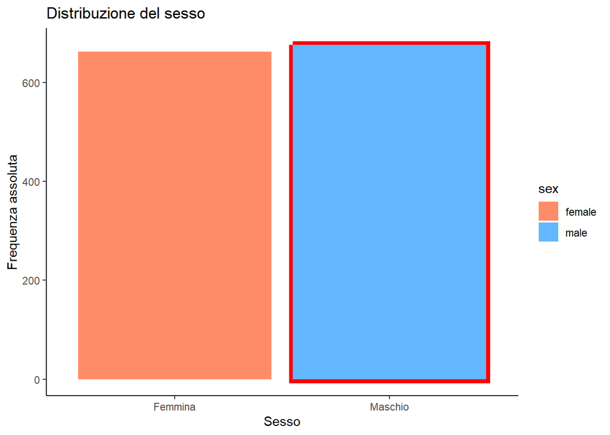

Si osserva graficamente come la distribuzione del sesso degli assicurati sia **simmetrica**: si tratta di 662 assicurati di sesso femminile (circa 49,5%) e di 676 assicurati di sesso maschile (circa 50,5%).

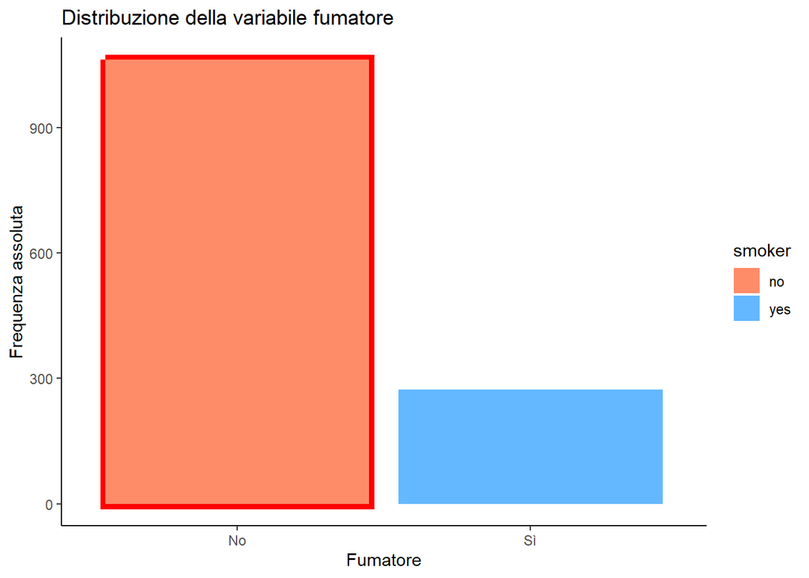

Non vale la stessa cosa per i fumatori: la distribuzione è **fortemente asimmetrica**, infatti si parla di 274 fumatori (circa 20%) contro 1064 non fumatori (circa 80%).

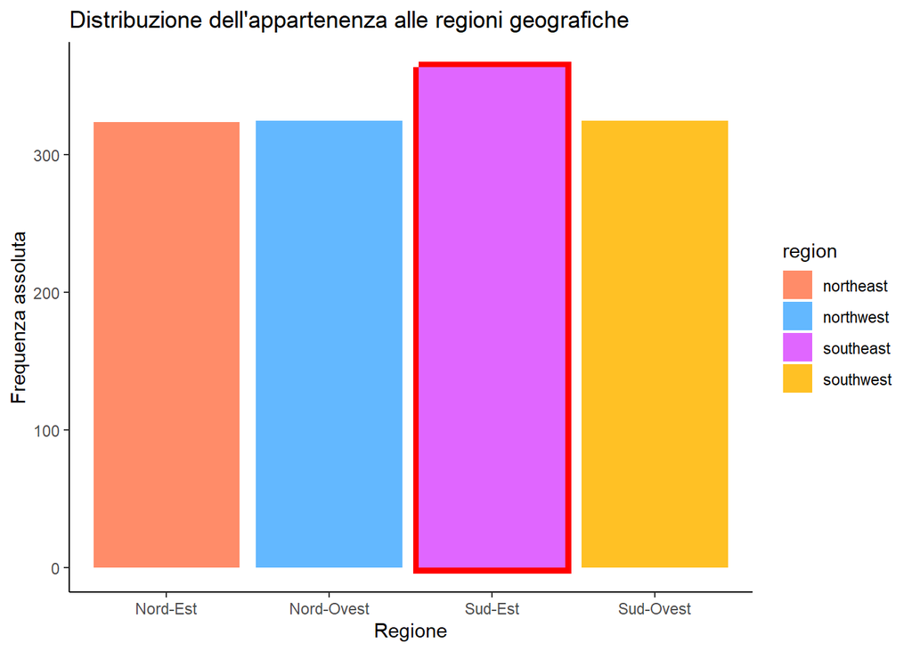

La regione geografica di appartenenza, invece, ha nuovamente una distribuzione **simmetrica**: si hanno 324 assicurati dal Nord-Est (circa 24%), 325 assicurati dal Nord-Ovest (circa 24%), 364 assicurati dal Sud-Est (circa 27%) e 325 assicurati dal Sud-Ovest (circa 24%).

Un’ulteriore variabile che può essere considerata categorica, sebbene la sua natura quantitativa discreta, è il **numero dei figli**, grazie al **numero ridotto di determinazioni** che assume. Si osserva la distribuzione attraverso un barplot:

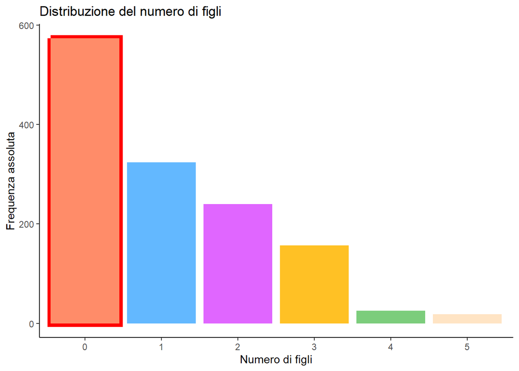

Si osserva come la variabile presenti un’**asimmetria positiva**: infatti, buona parte delle persone non hanno figli (42.8%), mentre le altre categorie presentano rispettivamente le seguenti proporzioni: 24.2%, 18.0%, 11.8%, 1.9%, fino all’1.3% rappresentato da famiglie con 5 figli.

### **Spese mediche condizionate al numero di figli**

Si rappresentano le spese mediche condizionate al numero di figli; prima di effettuare l’analisi grafica, è stata creata una nuova variabile nel dataset, rappresentante il numero di figli in cui tutte le famiglie con 3 o più figli sono accorpate nell’unica determinazione “**3+**”. La nuova variabile è stata salvata come variabile **categoriale**.

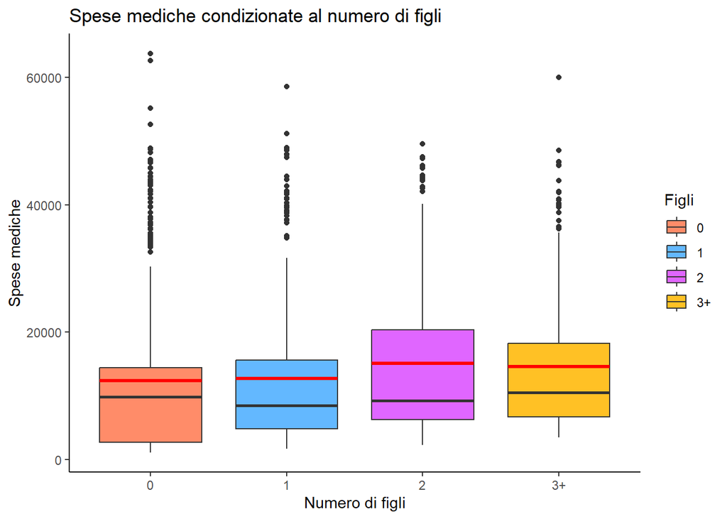

Dal grafico emerge subito una forte **asimmetria a destra** nei dati per tutte le quattro le distribuzioni condizionate, come si evince da diversi aspetti: la presenza di numerosi **punti anomali** al di sopra dei baffi, l’assenza di un punto anomalo nella zona inferiore; la lunghezza del baffo punta alla stessa conclusione, osservando come quelli inferiori siano tutti molto corti; inoltre, la mediana, ad eccezione della prima classe, si trova più vicina al primo quartile rispetto al terzo; infine, sfruttando la linea rossa rappresentante la **media**, si osserva come essa sia **sempre superiore alla mediana**. Tutti questi fattori sono indici di **asimmetria positiva**.

### **Spese mediche condizionate all’indice di massa corporea**

Come prima cosa, per le rappresentazioni grafiche, è stata creata la variabile bmicat come descritto nella consegna, divisa nelle 4 categorie underweight, normal, overweight e obese.

Si rappresentano graficamente i 4 **istogrammi** della distribuzione delle frequenze assolute delle spese mediche, ciascuno per una categoria di BMI (**Body Mass Index**).

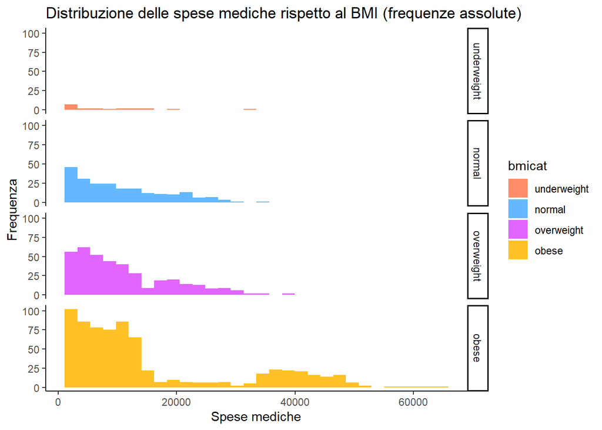

Si costruiscono ora i grafici delle distribuzioni delle frequenze relative, così da poterci sovrapporre le **funzioni di densità empiriche**:

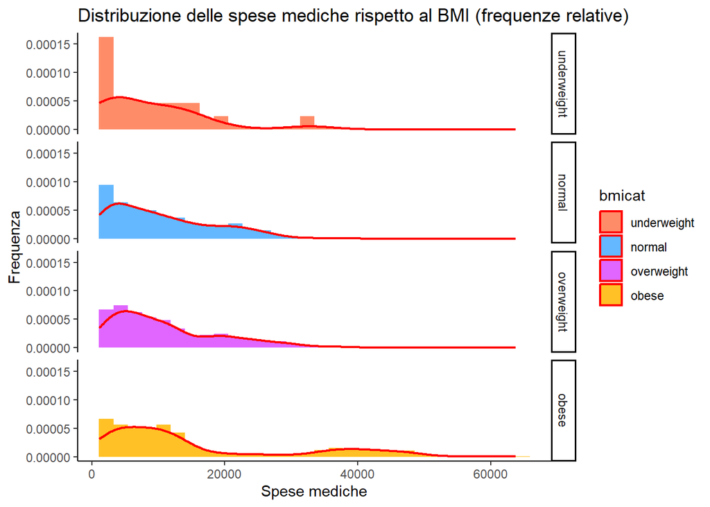

### **Relazione tra l’indice di massa e il sesso**

Si studia la possibile correlazione tra l’indice di massa corporea e il sesso. Prima di tutto si effettua uno studio preliminare grafico:

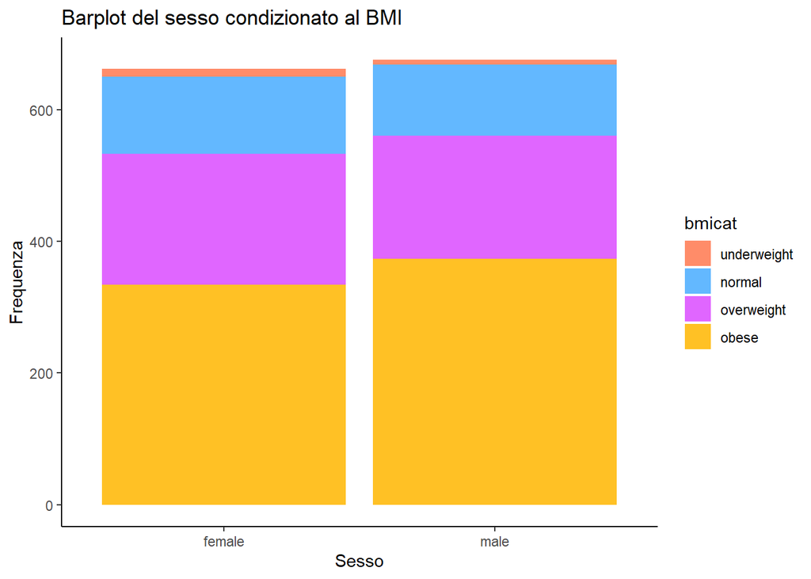

Questo primo grafico suggerisce già una scarsa correlazione tra le variabili, poiché sembra che le **proporzioni di maschi e femmine**, a seconda dell’indice di massa corporea, siano coerenti; le differenze più evidenti sono che i maschi hanno un BMI leggermente superiore, essendo la frequenza delle persone obese è maggiore negli uomini rispetto che nelle donne, a discapito di quelle sottopeso, maggiormente presente nelle femmine.

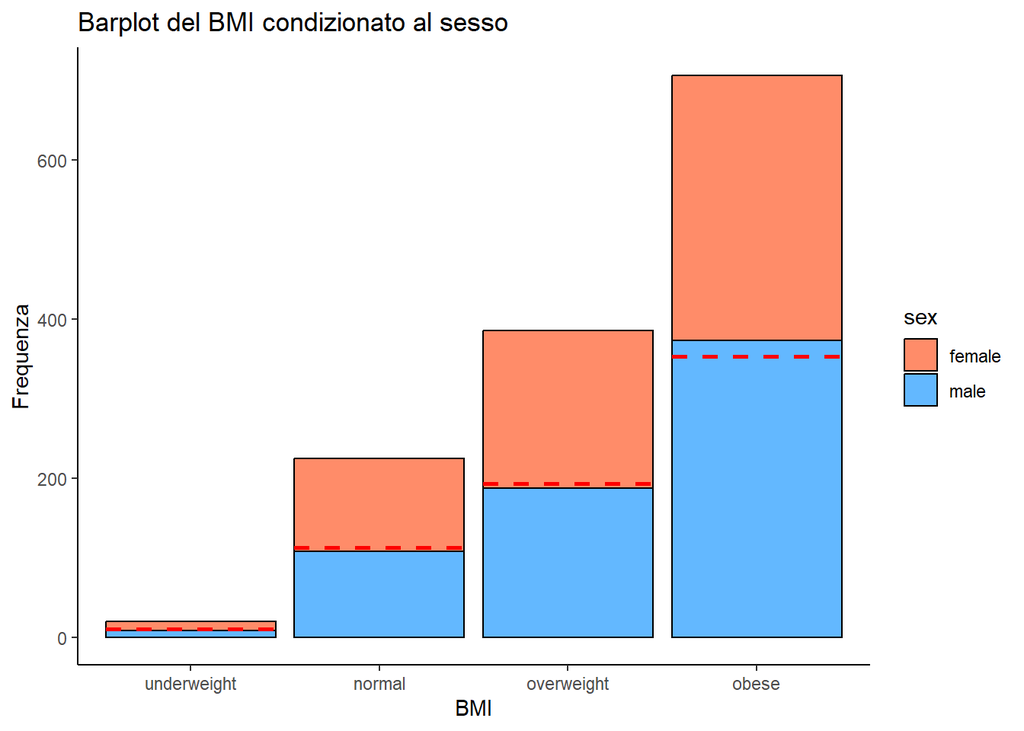

Il secondo grafico è più chiaro, e risulta **plausibile pensare che le due variabili siano indipendenti**; in particolare, a questo grafico è stata aggiunta una linea rossa tratteggiata a metà dell’altezza della barra, e può tornare utile per vedere quanto la proporzione di maschi e femmine si discosta da tale linea. Questo sistema è attendibile esclusivamente perché la percentuale di maschi e femmine presenti è pressoché 50% per categoria.

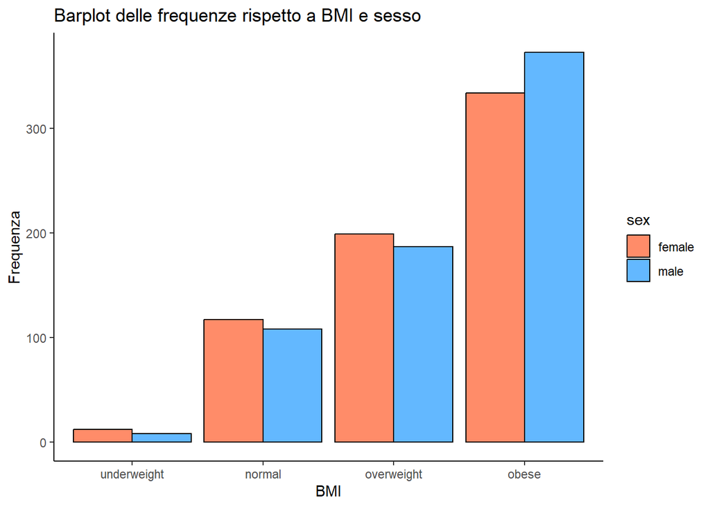

L’ultimo grafico è la conferma di quanto osservato fin’ora: le proporzioni tra maschio e femmina, a parità di livello di BMI, sono molto simili, a meno di un piccolo scarto. Ora cerchiamo conferma delle considerazioni effettuate graficamente usando un indice analitico: l’indice del $X^2$. Per effettuare il test del $X^2$ si assume un livello di confidenza del 95%.

```
##
##  Pearson's Chi-squared test
##
## data:  tab1
## X-squared = 3.5383, df = 3, p-value = 0.3158
```

### **Relazione tra spese mediche, età e fumo**

In questo ultimo paragrafo si osserva la relazione che intercorre tra le variabili spese mediche, età e fumo; sia le spese mediche che l’età sono variabili quantitative, pertanto è possibile utilizzare un **grafico di dispersione** per poterle analizzare:

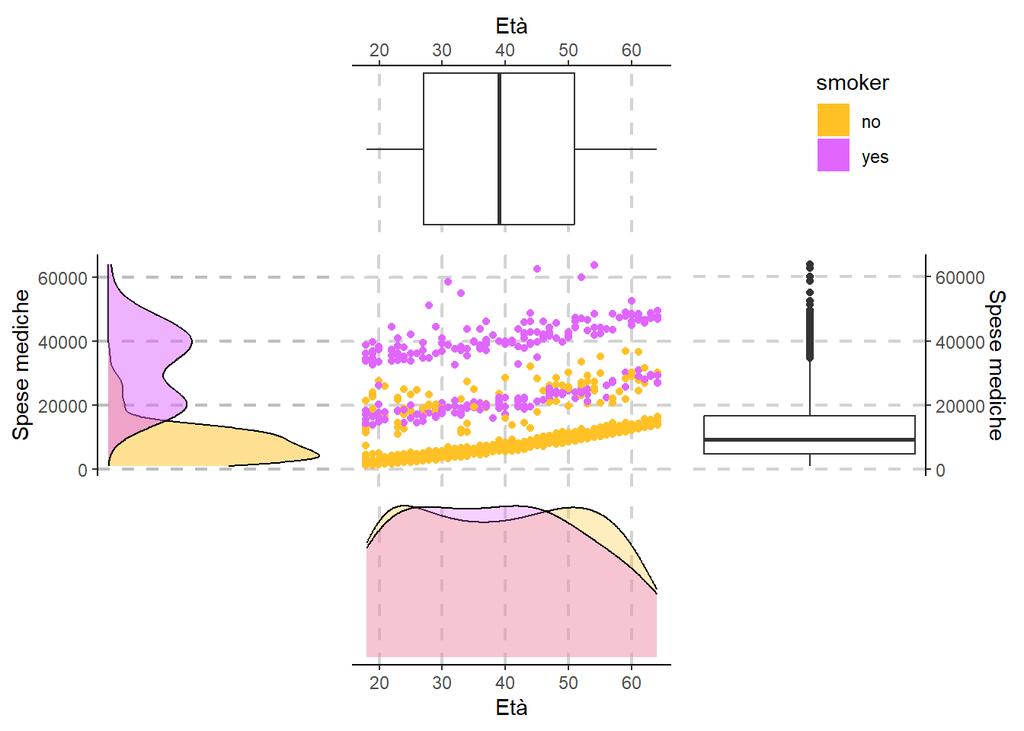

Il grafico principale mostra già come mediamente le spese mediche aumentino lievemente con l’aumentare dell’età e invece si può notare una **forte distinzione** tra le spese mediche a carico di **fumatori** e quelle dei **non fumatori**. Analizzando il grafico di densità della variabile **“charges”** in relazione a **“smoker”** possiamo infatti notare come le persone che non fumano si concentrano tra i valori **0** e **20000**, mentre i fumatori presentano una **distribuzione bimodale** con i picchi in corrispondenza dei valori **20000** e **40000**. Il secondo grafico della densità mostra come l’età e l’essere fumatori non sono fattori fortemente dipendenti (test del $X^2$ con ipotesi nulla di indipendenza risulta un p-value di 0.24); si può notare come il livello di fumatori cala più velocemente una volta superati i 50 anni, ma con il campione di dati a disposizione non si possono trarre conclusioni rilevanti da questa osservazione. Nel **boxplot** relativo all’età delle persone di cui sono stati raccolti i dati, possiamo notare una forma regolare della scatola e la mediana posizionata quasi a metà, indice di una distribuzione simmetrica della variabile nell’intervallo 18-64. Il boxplot relativo alle spese mediche mostra come la scatola sia posizionata molto in basso rispetto all’intero range dei dati e di come ci siano diversi valori indicati come **outlayers**; il fenomeno si verifica perché i dati dei fumatori sono molti meno rispetto agli altri e quindi non sono sufficienti a modificare significativamente la posizione della scatola.

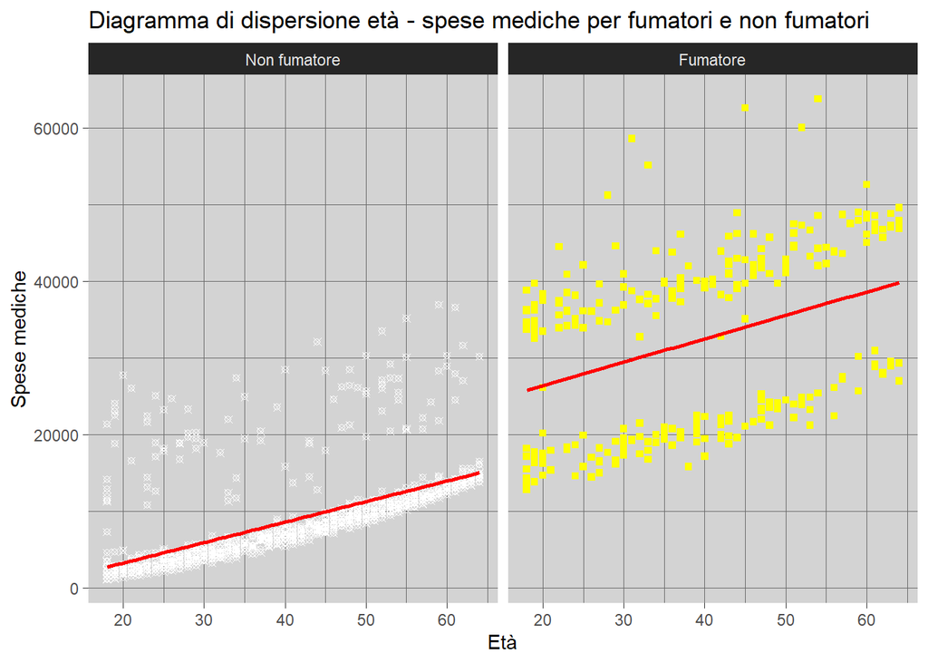

L’ultimo grafico, in cui sono presenti anche le **rette di regressione**, conferma quanto affermato in precedenza: emerge in modo evidente la correlazione positiva tra età e spese mediche e la forte influenza del fumo sulle spese. Graficamente si nota come le due rette di regressione per dati di non fumatori e fumatori siano approssimativamente parallele: ciò significa che il valore della variabile dicotomica **“smoker”** (0 / 1) incide sull’**intercetta** della retta, ma non c’è interazione significativa con la variabile **“age”**.